# Marauding Lesbia Plots

Boris Igić and Phil Fenberg

2020-02-29

```r
library(ggplot2)
library(RColorBrewer) # for brewer.pal() color palette
library(cowplot) # for plot_grid()
#bandits<-read.csv(file = "/Users/boris/Dropbox/PROJECTS/nectar-robbing/larceny-paper/entered_data/robber_dbase_v1.1-lesbia.csv", header=T, as.is=T)
bandits<-read.csv(file = "/Users/boris/Dropbox/PROJECTS/nectar-robbing/larceny-paper/entered_data/robber_dbase_v1.1b-lesbia.csv", header=T, as.is=T)

#should repeat this (below) on:
#(1) original csv data, instead of magic numbers
#(2) separated by Lesbia species

split.bandits <- split(bandits,bandits$bird.genus)
lesbias <- split.bandits$Lesbia
diglossas <- split.bandits$Diglossa
```

### Summary Stats

We take a look at some summary statistics, mostly by checking tables of the mode of plant-trainbearer interaction, semi-manually extract and re-order levels/factors for that data to later make a bar plot. We also check that there are no unexpected associations with sex (m/f) and species (nuna/victoriae, ignoring uncertain sp. designation).

```r
# How many L. nuna, L. victoriae, and "sp."
dim(lesbias)
```

```
## [1] 180  16
```

```r
table(lesbias$bird.species)
```

```
##
##      nuna       sp. victoriae
##        59        27        94
```

```r
# sex: roughly similar number of males and females
sum(table(lesbias$bird.sex))
```

```
## [1] 170
```

```r
table(lesbias$bird.sex)
```

```
##
##  f  m
## 75 95
```

```r
# visitor mode
sum(table(lesbias$visitor.mode))
```

```
## [1] 135
```

```r
sum(is.na(lesbias$visitor.mode))
```

```
## [1] 45
```

```r
# Raw numbers
table(lesbias$visitor.mode)
```

```
##
##  NR NR2   P P/T   T
##  41  10  36  46   2
```

```r
# Proportions
round(table(lesbias$visitor.mode)/sum(table(lesbias$visitor.mode)),digits=3)
```

```
##
##    NR   NR2     P   P/T     T
## 0.304 0.074 0.267 0.341 0.015
```

```r
# plant genera visited (and IDed)
sum(table(lesbias$plant.genus))
```

```
## [1] 180
```

```r
table(lesbias$plant.genus)[order(table(lesbias$plant.genus))]
```

```
##
##         Bejaria       Caiophora          Carica     Cavendishia
##               1               1               1               1
##         Cestrum        Dunalia?       Ericaceae     Eucalyptus?
##               1               1               1               1
##       Impatiens       Iochroma?        Lonicera Melastomataceae
##               1               1               1               1
##         Monocot        Opuntia?      Solanaceae      Tropaeolum
##               1               1               1               1
##           Vinca     Antirrhinum           Canna      Chuquiraga
##               1               2               2               2
##       Digitalis       Erythrina      Eucalyptus        Hibiscus
##               2               2               2               2
##        Iochroma    Alstroemeria      Asteraceae      Passiflora
##               2               3               3               3
##     Pittosporum  Stachytarpheta    Streptosolen      Agapanthus
##               3               3               4               6
##            Aloe          Tecoma         Lantana       Nicotiana
##               6               6               7               7
##     Callistemon      Brugmansia        Leonotis          Salvia
##               8               9               9              11
##        Abutilon               ?         Fuchsia
##              12              22              25
```

Let’s set up the catergories to be plotted. Two plots: one will include unknown modes and one will exclude them.

```r
# TOTAL RAW DATA
lesbia.tally <- data.frame(modes=as.factor(c("R2","R1/R2","T","T/P","P","UNK")),
           obs=c(sum(lesbias$visitor.mode=="NR2",na.rm = T),
          sum(lesbias$visitor.mode=="NR",na.rm = T),
          sum(lesbias$visitor.mode=="T",na.rm = T),
          sum(lesbias$visitor.mode=="P/T",na.rm = T),
          sum(lesbias$visitor.mode=="P",na.rm = T),
          sum(is.na(lesbias$visitor.mode)))
          )
# This is the total tally for all Lesbias:
lesbia.tally
```

```
##   modes obs
## 1    R2  10
## 2 R1/R2  41
## 3     T   2
## 4   T/P  46
## 5     P  36
## 6   UNK  45
```

```r
# Set factors into desired plotting order
lesbia.tally$modes <- factor(lesbia.tally$modes, levels = c("R2","R1/R2","T","T/P","P","UNK"))

# convert observations into percentages
lesbia.tally$perc <- (lesbia.tally$obs/sum(lesbia.tally$obs))*100
les.tally.perc<-lesbia.tally$perc
names(les.tally.perc)<-lesbia.tally$modes
round(les.tally.perc,2)
```

```
##    R2 R1/R2     T   T/P     P   UNK
##  5.56 22.78  1.11 25.56 20.00 25.00
```

```r
# TOTAL RAW DATA
lesbia.noNA <- data.frame(modes=as.factor(c("R2","R1/R2","T","T/P","P")),
           obs=c(sum(lesbias$visitor.mode=="NR2",na.rm = T),
          sum(lesbias$visitor.mode=="NR",na.rm = T),
          sum(lesbias$visitor.mode=="T",na.rm = T),
          sum(lesbias$visitor.mode=="P/T",na.rm = T),
          sum(lesbias$visitor.mode=="P",na.rm = T)
          ))
# This is the total tally for all Lesbias:
lesbia.noNA
```

```
##   modes obs
## 1    R2  10
## 2 R1/R2  41
## 3     T   2
## 4   T/P  46
## 5     P  36
```

```r
# Set factors into desired plotting order
lesbia.noNA$modes <- factor(lesbia.noNA$modes, levels = c("R2","R1/R2","T","T/P","P"))

# convert observations into percentages
lesbia.noNA$perc <- (lesbia.noNA$obs/sum(lesbia.noNA$obs))*100
lesbia.noNA$perc
```

```
## [1]  7.407407 30.370370  1.481481 34.074074 26.666667
```

```r
les.noNA.perc<-lesbia.noNA$perc
names(les.noNA.perc)<-lesbia.noNA$modes
round(les.noNA.perc,2)
```

```
##    R2 R1/R2     T   T/P     P
##  7.41 30.37  1.48 34.07 26.67
```

### Sex and Species

Now, let’s check whether there are sex- or species-dependent associations. We don’t expect any, a priori. To facilitate this, we’re splitting the visits into two broad catergories: larceny (NR1,NR2,T, and any combinations thereof) and pollination (P,P/T).

```r
#
#Check whether there are sex-dependent differences v1
#

les.sex.not.na<-complete.cases(lesbias[,c(which(names(lesbias)=="bird.sex"),which(names(lesbias)=="visitor.mode"))])

sex_mode <- lesbias[,c(which(names(lesbias)=="bird.sex"),which(names(lesbias)=="visitor.mode"))][les.sex.not.na,]
table(split(sex_mode,sex_mode$bird.sex)$m)
```

```
##         visitor.mode
## bird.sex NR NR2  P P/T
##        m 29   6 14  27
```

```r
table(split(sex_mode,sex_mode$bird.sex)$f)
```

```
##         visitor.mode
## bird.sex NR NR2  P P/T  T
##        f  9   4 21  15  1
```

```r
f.larceny<-table(split(sex_mode,sex_mode$bird.sex)$f)[1]+table(split(sex_mode,sex_mode$bird.sex)$f)[2]+table(split(sex_mode,sex_mode$bird.sex)$f)[5]

f.pollination <- table(split(sex_mode,sex_mode$bird.sex)$f)[3]+table(split(sex_mode,sex_mode$bird.sex)$f)[4]

m.larceny<-table(split(sex_mode,sex_mode$bird.sex)$m)[1]+table(split(sex_mode,sex_mode$bird.sex)$m)[2]

m.pollination <- table(split(sex_mode,sex_mode$bird.sex)$m)[3]+table(split(sex_mode,sex_mode$bird.sex)$m)[4]


les.by.sex <-
matrix(c(m.larceny, f.larceny, m.pollination, f.pollination), #these were manually added from above lines
       nrow = 2,
       dimnames =
       list(c("male", "female"),
            c("larceny", "pollination")))

les.by.sex
```

```
##        larceny pollination
## male        35          41
## female      14          36
```

```r
fisher.test(les.by.sex)
```

```
##
##  Fisher's Exact Test for Count Data
##
## data:  les.by.sex
## p-value = 0.06126
## alternative hypothesis: true odds ratio is not equal to 1
## 95 percent confidence interval:
##  0.9627928 5.1250728
## sample estimates:
## odds ratio
##   2.181498
```

```r
#
#Check whether there are spp-dependent differences v1
#

les.sp.not.na<-complete.cases(lesbias[,c(which(names(lesbias)=="bird.species"),which(names(lesbias)=="visitor.mode"))])
sp_mode <- lesbias[,c(1:16)][les.sp.not.na,]
nun <- split(sp_mode,sp_mode$bird.species)$nuna
vic <- split(sp_mode,sp_mode$bird.species)$victoriae
table(nun$visitor.mode)
```

```
##
##  NR NR2   P P/T
##   9   4  17  15
```

```r
table(vic$visitor.mode)
```

```
##
##  NR NR2   P P/T   T
##  28   6  17  22   2
```

```r
n.larceny<-table(nun$visitor.mode)[1]+table(nun$visitor.mode)[2]

n.pollination <- table(nun$visitor.mode)[3]+table(nun$visitor.mode)[4]

v.larceny<-table(vic$visitor.mode)[1]+table(vic$visitor.mode)[2]+table(vic$visitor.mode)[5]

v.pollination <- table(vic$visitor.mode)[3]+table(vic$visitor.mode)[4]

les.by.sp <-
matrix(c(n.larceny, v.larceny, n.pollination, v.pollination), #these were manually added from above lines
       nrow = 2,
       dimnames =
       list(c("nuna", "victoriae"),
            c("larceny", "pollination")))

les.by.sp
```

```
##           larceny pollination
## nuna           13          32
## victoriae      36          39
```

```r
fisher.test(les.by.sp)
```

```
##
##  Fisher's Exact Test for Count Data
##
## data:  les.by.sp
## p-value = 0.05471
## alternative hypothesis: true odds ratio is not equal to 1
## 95 percent confidence interval:
##  0.1830762 1.0301087
## sample estimates:
## odds ratio
##  0.4431191
```

```r
lesbias$mode.bin<-lesbias$visitor.mode
lesbias$mode.bin[lesbias$visitor.mode=="NR"]<-"robbing"
lesbias$mode.bin[lesbias$visitor.mode=="NR2"]<-"robbing"
lesbias$mode.bin[lesbias$visitor.mode=="T"]<-"other"
lesbias$mode.bin[lesbias$visitor.mode=="T/P"]<-"other"
lesbias$mode.bin[lesbias$visitor.mode=="P/T"]<-"other"
lesbias$mode.bin[lesbias$visitor.mode=="P"]<-"other"

# Get rid of no species ID rows
split.lesbias <- split(lesbias,lesbias$bird.species)
victoriae <- split.lesbias$victoriae
nuna <- split.lesbias$nuna

lesbias.new <- rbind(nuna,victoriae)
lesbias.xtab <- xtabs( ~ bird.species + mode.bin + bird.sex, data = lesbias.new)

library(vcd)
library(vcdExtra)
```

```r
library(MASS)

# simple summaries
pdf(width=8,height=6,file="mosaic-plot.pdf")
mosaic(lesbias.xtab, shade=T)
dev.off()
```

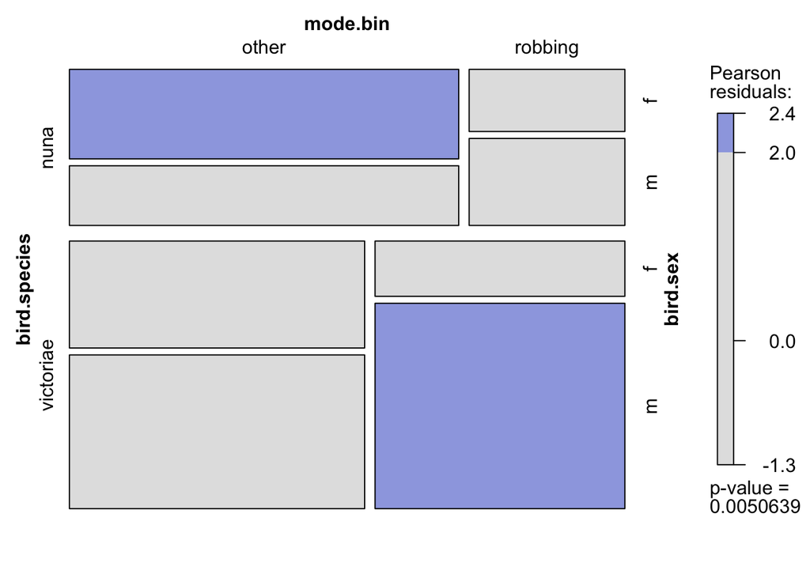

```r
lesbias.table<-mosaic(lesbias.xtab, shade=T)
```

```r
lesbias.table
```

```
##                       mode.bin other robbing
## bird.species bird.sex
## nuna         f                    18       5
##              m                    12       7
## victoriae    f                    16       7
##              m                    23      26
```

```r
structable(lesbias.table)
```

```
##                       mode.bin other robbing
## bird.species bird.sex
## nuna         f                    18       5
##              m                    12       7
## victoriae    f                    16       7
##              m                    23      26
```

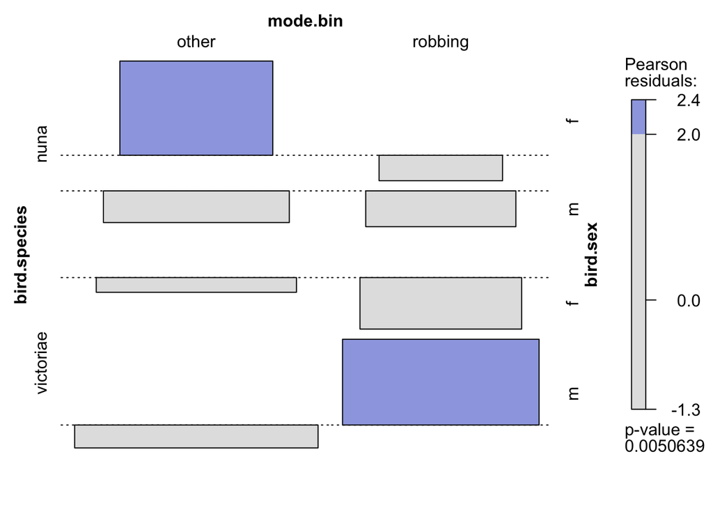

```r
assoc(lesbias.xtab, shade=TRUE)
```

```r
assocstats(lesbias.xtab)
```

```
## $`bird.sex:f`
##                      X^2 df P(> X^2)
## Likelihood Ratio 0.45261  1  0.50110
## Pearson          0.45098  1  0.50187
##
## Phi-Coefficient   : 0.099
## Contingency Coeff.: 0.099
## Cramer's V        : 0.099
##
## $`bird.sex:m`
##                     X^2 df P(> X^2)
## Likelihood Ratio 1.4564  1  0.22751
## Pearson          1.4419  1  0.22983
##
## Phi-Coefficient   : 0.146
## Contingency Coeff.: 0.144
## Cramer's V        : 0.146
```

```r
# Statistical tests
summary(lesbias.xtab) # outputs chi-square test
```

```
## Call: xtabs(formula = ~bird.species + mode.bin + bird.sex, data = lesbias.new)
## Number of cases in table: 114
## Number of factors: 3
## Test for independence of all factors:
##  Chisq = 14.831, df = 4, p-value = 0.005064
```

## Model Testing

It seems that the best model is Conditional Independence: mode is independent of species, given sex (mod_cond_1A).

```r
# https://www.statmethods.net/advgraphs/mosaic.html
# https://www.statmethods.net/stats/frequencies.html
# http://www.datavis.ca/courses/VCD/vcd-tutorial.pdf
# http://haleyjeppson.github.io/ggmosaic/articles/ggmosaic.html


mod_ind<-loglm(~ mode.bin + bird.species + bird.sex, lesbias.xtab)
mod_ind
```

```
## Call:
## loglm(formula = ~mode.bin + bird.species + bird.sex, data = lesbias.xtab)
##
## Statistics:
##                       X^2 df    P(> X^2)
## Likelihood Ratio 13.55554  4 0.008857397
## Pearson          14.83142  4 0.005063949
```

```r
anova(mod_ind)
```

```
## Call:
## loglm(formula = ~mode.bin + bird.species + bird.sex, data = lesbias.xtab)
##
## Statistics:
##                       X^2 df    P(> X^2)
## Likelihood Ratio 13.55554  4 0.008857397
## Pearson          14.83142  4 0.005063949
```

```r
# Partial Independence: mode is partially independent of composite variable sex*species
mod_part_ind1<-loglm(~ mode.bin + bird.species + bird.sex + bird.species * bird.sex, lesbias.xtab)
mod_part_ind1
```

```
## Call:
## loglm(formula = ~mode.bin + bird.species + bird.sex + bird.species *
##     bird.sex, data = lesbias.xtab)
##
## Statistics:
##                       X^2 df   P(> X^2)
## Likelihood Ratio 7.841985  3 0.04939280
## Pearson          7.655708  3 0.05368978
```

```r
# Conditional Independence: mode is independent of species, given sex
mod_cond_1A<-loglm(~ mode.bin + bird.species + bird.sex + mode.bin * bird.sex + bird.species * bird.sex, lesbias.xtab)
mod_cond_1A
```

```
## Call:
## loglm(formula = ~mode.bin + bird.species + bird.sex + mode.bin *
##     bird.sex + bird.species * bird.sex, data = lesbias.xtab)
##
## Statistics:
##                       X^2 df  P(> X^2)
## Likelihood Ratio 1.908979  2 0.3850087
## Pearson          1.892867  2 0.3881228
```

```r
#mod_cond_2<-loglm(~ mode.bin + bird.species * bird.sex, lesbias.xtab)
#mod_cond_2

#mod_cond_3<-loglm(~ (mode.bin + bird.species) * bird.sex, lesbias.xtab)
#mod_cond_3

#mod_cond_4<-loglm(~ (mode.bin + bird.sex) * bird.species, lesbias.xtab)
#mod_cond_4

# Conditional Independence: mode is independent of sex, given species
mod_cond_1B<-loglm(~ mode.bin + bird.species + bird.sex + mode.bin * bird.species + bird.sex * bird.species, lesbias.xtab)
mod_cond_1B
```

```
## Call:
## loglm(formula = ~mode.bin + bird.species + bird.sex + mode.bin *
##     bird.species + bird.sex * bird.species, data = lesbias.xtab)
##
## Statistics:
##                       X^2 df  P(> X^2)
## Likelihood Ratio 4.462320  2 0.1074038
## Pearson          4.390757  2 0.1113164
```

```r
# All two-way interactions
#mod_all2way<-loglm(~ mode.bin * bird.species + mode.bin * bird.sex + bird.species * bird.sex, lesbias.xtab)
#mod_all2way

# No Three-Way Interaction
mod_no3way_1<-loglm(~ mode.bin + bird.species + bird.sex + mode.bin * bird.species + bird.species * bird.sex + mode.bin * bird.sex, lesbias.xtab)
mod_no3way_1
```

```
## Call:
## loglm(formula = ~mode.bin + bird.species + bird.sex + mode.bin *
##     bird.species + bird.species * bird.sex + mode.bin * bird.sex,
##     data = lesbias.xtab)
##
## Statistics:
##                         X^2 df  P(> X^2)
## Likelihood Ratio 0.05586601  1 0.8131534
## Pearson          0.05593530  1 0.8130397
```

```r
mod_3way_2<-loglm(~ mode.bin * bird.species * bird.sex, lesbias.xtab)
mod_3way_2
```

```
## Call:
## loglm(formula = ~mode.bin * bird.species * bird.sex, data = lesbias.xtab)
##
## Statistics:
##                  X^2 df P(> X^2)
## Likelihood Ratio   0  0        1
## Pearson            0  0        1
```

```r
anova(mod_ind,mod_no3way_1)
```

```
## LR tests for hierarchical log-linear models
##
## Model 1:
##  ~mode.bin + bird.species + bird.sex
## Model 2:
##  ~mode.bin + bird.species + bird.sex + mode.bin * bird.species + bird.species * bird.sex + mode.bin * bird.sex
##
##              Deviance df  Delta(Dev) Delta(df) P(> Delta(Dev)
## Model 1   13.55554450  4
## Model 2    0.05586601  1 13.49967848         3        0.00367
## Saturated  0.00000000  0  0.05586601         1        0.81315
```

```r
anova(mod_ind,mod_part_ind1)
```

```
## LR tests for hierarchical log-linear models
##
## Model 1:
##  ~mode.bin + bird.species + bird.sex
## Model 2:
##  ~mode.bin + bird.species + bird.sex + bird.species * bird.sex
##
##            Deviance df Delta(Dev) Delta(df) P(> Delta(Dev)
## Model 1   13.555544  4
## Model 2    7.841985  3   5.713559         1        0.01683
## Saturated  0.000000  0   7.841985         3        0.04939
```

```r
anova(mod_ind,mod_cond_1B)
```

```
## LR tests for hierarchical log-linear models
##
## Model 1:
##  ~mode.bin + bird.species + bird.sex
## Model 2:
##  ~mode.bin + bird.species + bird.sex + mode.bin * bird.species + bird.sex * bird.species
##
##           Deviance df Delta(Dev) Delta(df) P(> Delta(Dev)
## Model 1   13.55554  4
## Model 2    4.46232  2   9.093224         2         0.0106
## Saturated  0.00000  0   4.462320         2         0.1074
```

```r
anova(mod_ind,mod_cond_1A)
```

```
## LR tests for hierarchical log-linear models
##
## Model 1:
##  ~mode.bin + bird.species + bird.sex
## Model 2:
##  ~mode.bin + bird.species + bird.sex + mode.bin * bird.sex + bird.species * bird.sex
##
##            Deviance df Delta(Dev) Delta(df) P(> Delta(Dev)
## Model 1   13.555544  4
## Model 2    1.908979  2  11.646566         2        0.00296
## Saturated  0.000000  0   1.908979         2        0.38501
```

```r
anova(mod_cond_1A,mod_cond_1B)
```

```
## LR tests for hierarchical log-linear models
##
## Model 1:
##  ~mode.bin + bird.species + bird.sex + mode.bin * bird.sex + bird.species * bird.sex
## Model 2:
##  ~mode.bin + bird.species + bird.sex + mode.bin * bird.species + bird.sex * bird.species
##
##           Deviance df Delta(Dev) Delta(df) P(> Delta(Dev)
## Model 1   1.908979  2
## Model 2   4.462320  2  -2.553341         0         1.0000
## Saturated 0.000000  0   4.462320         2         0.1074
```

```r
anova(mod_ind,mod_part_ind1,mod_cond_1A,mod_cond_1B,mod_no3way_1)
```

```
## LR tests for hierarchical log-linear models
##
## Model 1:
##  ~mode.bin + bird.species + bird.sex
## Model 2:
##  ~mode.bin + bird.species + bird.sex + bird.species * bird.sex
## Model 3:
##  ~mode.bin + bird.species + bird.sex + mode.bin * bird.sex + bird.species * bird.sex
## Model 4:
##  ~mode.bin + bird.species + bird.sex + mode.bin * bird.species + bird.sex * bird.species
## Model 5:
##  ~mode.bin + bird.species + bird.sex + mode.bin * bird.species + bird.species * bird.sex + mode.bin * bird.sex
##
##              Deviance df  Delta(Dev) Delta(df) P(> Delta(Dev)
## Model 1   13.55554450  4
## Model 2    7.84198543  3  5.71355907         1        0.01683
## Model 3    1.90897866  2  5.93300677         1        0.01486
## Model 4    4.46232003  2 -2.55334137         0        1.00000
## Model 5    0.05586601  1  4.40645402         1        0.03580
## Saturated  0.00000000  0  0.05586601         1        0.81315
```

```r
LRstats(mod_ind,mod_part_ind1,mod_cond_1A,mod_cond_1B,mod_no3way_1)
```

```
## Likelihood summary table:
##                  AIC    BIC LR Chisq Df Pr(>Chisq)
## mod_ind       56.429 56.747  13.5555  4   0.008857 **
## mod_part_ind1 52.716 53.113   7.8420  3   0.049393 *
## mod_cond_1A   48.783 49.259   1.9090  2   0.385009
## mod_cond_1B   51.336 51.813   4.4623  2   0.107404
## mod_no3way_1  48.930 49.486   0.0559  1   0.813153
## ---
## Signif. codes:  0 '***' 0.001 '**' 0.01 '*' 0.05 '.' 0.1 ' ' 1
```

```r
anova(mod_ind,mod_part_ind1,mod_cond_1A,mod_no3way_1)
```

```
## LR tests for hierarchical log-linear models
##
## Model 1:
##  ~mode.bin + bird.species + bird.sex
## Model 2:
##  ~mode.bin + bird.species + bird.sex + bird.species * bird.sex
## Model 3:
##  ~mode.bin + bird.species + bird.sex + mode.bin * bird.sex + bird.species * bird.sex
## Model 4:
##  ~mode.bin + bird.species + bird.sex + mode.bin * bird.species + bird.species * bird.sex + mode.bin * bird.sex
##
##              Deviance df Delta(Dev) Delta(df) P(> Delta(Dev)
## Model 1   13.55554450  4
## Model 2    7.84198543  3 5.71355907         1        0.01683
## Model 3    1.90897866  2 5.93300677         1        0.01486
## Model 4    0.05586601  1 1.85311265         1        0.17342
## Saturated  0.00000000  0 0.05586601         1        0.81315
```

```r
LRstats(mod_ind,mod_part_ind1,mod_cond_1A,mod_no3way_1)
```

```
## Likelihood summary table:
##                  AIC    BIC LR Chisq Df Pr(>Chisq)
## mod_ind       56.429 56.747  13.5555  4   0.008857 **
## mod_part_ind1 52.716 53.113   7.8420  3   0.049393 *
## mod_cond_1A   48.783 49.259   1.9090  2   0.385009
## mod_no3way_1  48.930 49.486   0.0559  1   0.813153
## ---
## Signif. codes:  0 '***' 0.001 '**' 0.01 '*' 0.05 '.' 0.1 ' ' 1
```

### Set-up for plotting

This sets up plots by species, but it is specifically omitting NA/UNK entries, because it is using the values of nun and vic as calculated for the Fisher Tests (which omit them).

```r
#
#L. nuna
#
nun.tally <- data.frame(modes=as.factor(c("R2","R1/R2","T","T/P","P","UNK")),
           obs=c(sum(nun$visitor.mode=="NR2",na.rm = T),
          sum(nun$visitor.mode=="NR",na.rm = T),
          sum(nun$visitor.mode=="T",na.rm = T),
          sum(nun$visitor.mode=="P/T",na.rm = T),
          sum(nun$visitor.mode=="P",na.rm = T),
          sum(is.na(nun$visitor.mode)))
          )
# This is the total tally for all Lesbias:
nun.tally
```

```
##   modes obs
## 1    R2   4
## 2 R1/R2   9
## 3     T   0
## 4   T/P  15
## 5     P  17
## 6   UNK   0
```

```r
# Set factors into desired plotting order
nun.tally$modes <- factor(nun.tally$modes, levels = c("R2","R1/R2","T","T/P","P","UNK"))

# convert observations into percentages
nun.tally$perc <- (nun.tally$obs/sum(nun.tally$obs))*100

#
# L. victoriae
#

vic.tally <- data.frame(modes=as.factor(c("R2","R1/R2","T","T/P","P","UNK")),
           obs=c(sum(vic$visitor.mode=="NR2",na.rm = T),
          sum(vic$visitor.mode=="NR",na.rm = T),
          sum(vic$visitor.mode=="T",na.rm = T),
          sum(vic$visitor.mode=="P/T",na.rm = T),
          sum(vic$visitor.mode=="P",na.rm = T),
          sum(is.na(vic$visitor.mode)))
          )
# This is the total tally for all Lesbias:
vic.tally
```

```
##   modes obs
## 1    R2   6
## 2 R1/R2  28
## 3     T   2
## 4   T/P  22
## 5     P  17
## 6   UNK   0
```

```r
# Set factors into desired plotting order
vic.tally$modes <- factor(vic.tally$modes, levels = c("R2","R1/R2","T","T/P","P","UNK"))

# convert observations into percentages
vic.tally$perc <- (vic.tally$obs/sum(vic.tally$obs))*100
```

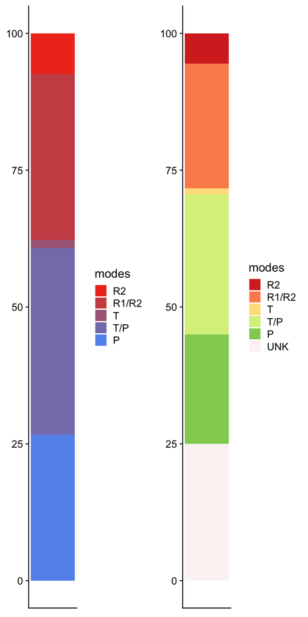

```r
# Colors for plotting
# this is a good red, #f03b20, ("#FEEACCFF") but the result with white is very porky flesh. Looks like bacon
# '#e6550d' with '#FEEDDDFF' looks pretty good, because it's orangey
# red to blue? #f03b20 to #a6bddb
# scale_fill_manual(values=brewer.pal(n=6, name='RdYlGn')) <-- this is great, but
# it needs a sixth white/off-white color added for "Interaction cannot be determined"

##f03b20, ("#FEEACCFF"
lesbia.col <- colorRampPalette(c('#f03b20','cornflowerblue')) # reddish to blueish
lesbia.cols <- alpha(lesbia.col(5))
RBW6 <- c(lesbia.cols,'#EAEFEDFF')

# First plotting attempt with red:blue:white and observation percentages WITHOUT UNKNOWN mode observations
l1 <- ggplot(lesbia.noNA, aes(1, perc, fill=modes)) +
  geom_bar(data=lesbia.noNA,stat="identity") +
  scale_fill_manual(values=RBW6) +
  theme(axis.title.x=element_blank(),
        axis.text.x=element_blank(),
        axis.ticks.x=element_blank(),
        axis.title.y=element_blank(),
        panel.grid.major = element_blank(),
        panel.grid.minor = element_blank(),
        panel.background = element_blank())

# Second plotting attempt with red:green:white and percentages, not observation counts
#scale_fill_manual(values=brewer.pal(n=6, name='RdYlGn'))

RGW6 <- brewer.pal(n=6, name='RdYlGn')
RGW6[6] <- '#FAEFEFAF'
l2 <- ggplot(lesbia.tally, aes(1, perc, fill=modes)) +
  geom_bar(data=lesbia.tally,stat="identity") +
  scale_fill_manual(values=RGW6) +
  theme(axis.title.x=element_blank(),
        axis.text.x=element_blank(),
        axis.ticks.x=element_blank(),
        axis.title.y=element_blank(),
        panel.grid.major = element_blank(),
        panel.grid.minor = element_blank(),
        panel.background = element_blank())
  # + scale_y_reverse()

plot_grid(l1, l2, ncol=2, align="v")
```

```r
# plot to file with pdf()
pdf(file="lesbia-fig1.pdf", height=10, width=5)
plot_grid(l1, l2, ncol=2, align="v")
dev.off()
```

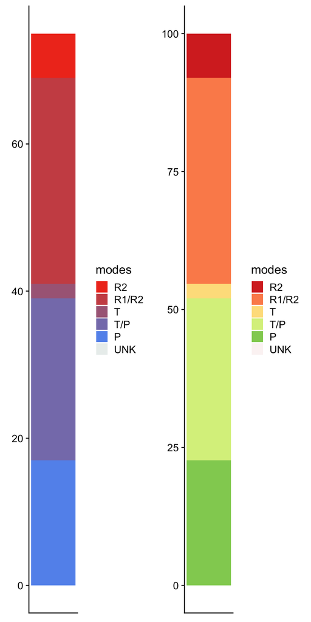

```r
#
# By Species Plots
#

# First plotting attempt with red:blue:white and observation counts, not percentages
v1 <- ggplot(vic.tally, aes(1, obs, fill=modes)) +
  geom_bar(data=vic.tally,stat="identity") +
  scale_fill_manual(values=RBW6) +
  theme(axis.title.x=element_blank(),
        axis.text.x=element_blank(),
        axis.ticks.x=element_blank(),
        axis.title.y=element_blank(),
        panel.grid.major = element_blank(),
        panel.grid.minor = element_blank(),
        panel.background = element_blank())

# Second plotting attempt with red:green:white and percentages, not observation counts
#scale_fill_manual(values=brewer.pal(n=6, name='RdYlGn'))

RGW6 <- brewer.pal(n=6, name='RdYlGn')
RGW6[6] <- '#FAEFEFAF'
v2 <- ggplot(vic.tally, aes(1, perc, fill=modes)) +
  geom_bar(data=vic.tally,stat="identity") +
  scale_fill_manual(values=RGW6) +
  theme(axis.title.x=element_blank(),
        axis.text.x=element_blank(),
        axis.ticks.x=element_blank(),
        axis.title.y=element_blank(),
        panel.grid.major = element_blank(),
        panel.grid.minor = element_blank(),
        panel.background = element_blank())
  # + scale_y_reverse()

plot_grid(v1, v2, ncol=2, align="v")
```

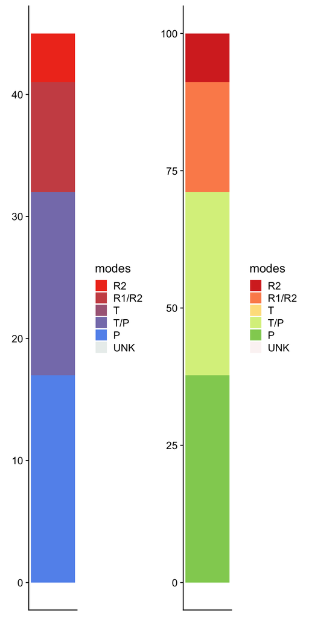

```r
# First plotting attempt with red:blue:white and observation counts, not percentages
n1 <- ggplot(nun.tally, aes(1, obs, fill=modes)) +
  geom_bar(data=nun.tally,stat="identity") +
  scale_fill_manual(values=RBW6) +
  theme(axis.title.x=element_blank(),
        axis.text.x=element_blank(),
        axis.ticks.x=element_blank(),
        axis.title.y=element_blank(),
        panel.grid.major = element_blank(),
        panel.grid.minor = element_blank(),
        panel.background = element_blank())

# Second plotting attempt with red:green:white and percentages, not observation counts
#scale_fill_manual(values=brewer.pal(n=6, name='RdYlGn'))

RGW6 <- brewer.pal(n=6, name='RdYlGn')
RGW6[6] <- '#FAEFEFAF'
n2 <- ggplot(nun.tally, aes(1, perc, fill=modes)) +
  geom_bar(data=nun.tally,stat="identity") +
  scale_fill_manual(values=RGW6) +
  theme(axis.title.x=element_blank(),
        axis.text.x=element_blank(),
        axis.ticks.x=element_blank(),
        axis.title.y=element_blank(),
        panel.grid.major = element_blank(),
        panel.grid.minor = element_blank(),
        panel.background = element_blank())
  # + scale_y_reverse()

plot_grid(n1, n2, ncol=2, align="v")
```

### Geographic Distribution

```r
library(dismo)
```

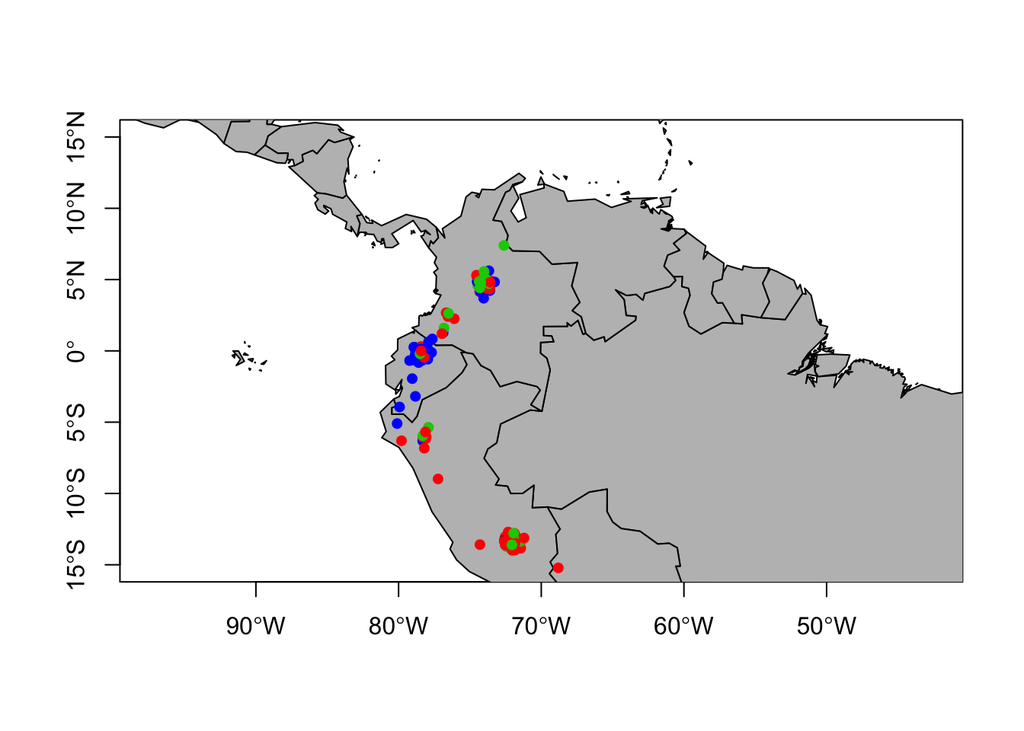

```r
library(maptools)
data(wrld_simpl)
plot(wrld_simpl, xlim=c(-85,-55), ylim=c(-15,15), axes=TRUE, col="grey")
# plot points
points(jitter(lesbias$lon[complete.cases(lesbias$lon)],amount = 0.5), jitter(lesbias$lat[complete.cases(lesbias$lat)],amount = 0.5), col=c("red", "green3", "blue")[unclass(factor(lesbias$bird.species[complete.cases(lesbias$lon)]))], pch=20, cex=1.25)
```

```r
#points(nun$lon[complete.cases(nun$lon)], nun$lat[complete.cases(nun$lat)], col='red', pch=20, cex=1.25)
#points(jitter(lesbias$lon[complete.cases(lesbias$lon)],amount = 0.5), jitter(lesbias$lat[complete.cases(lesbias$lat)], amount = 0.5), col='orange', pch=20, cex=1.25)
#points(jitter(nun$lon[complete.cases(nun$lon)],amount = 0.5), jitter(nun$lat[complete.cases(nun$lat)], amount = 0.5), col='red', pch=20, cex=1.25)
```

This is a color test that can be ignored, but is useful for selecting good plotting colors above.

```r
# brewer.pal
RGW6 <- brewer.pal(n=12, name='RdYlGn')
```

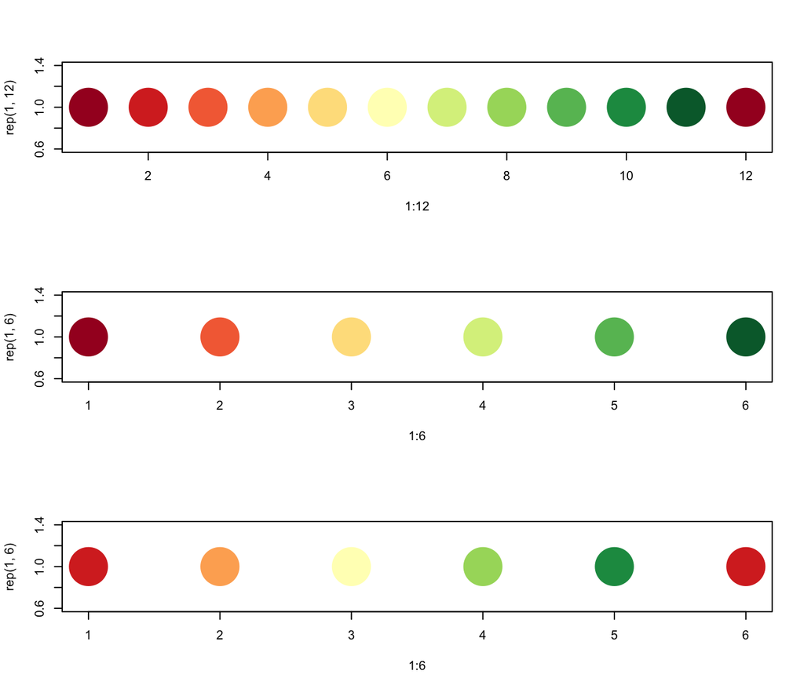

```r
par(mfrow=c(3,1))
plot(1:12,rep(1,12),pch=20,cex=10,col=RGW6)
plot(1:6,rep(1,6),pch=20,cex=10,col=RGW6[c(TRUE, FALSE)])
plot(1:6,rep(1,6),pch=20,cex=10,col=RGW6[c(F,T)])
```

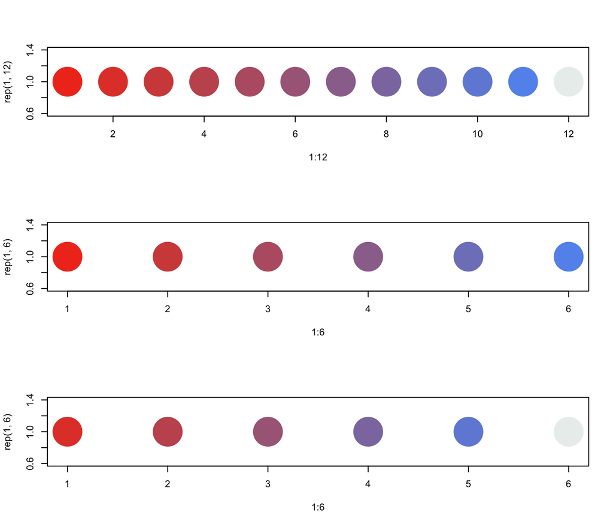

```r
# rcolorbrewer
lesbia.cols <- alpha(lesbia.col(11))
RBW6 <- c(lesbia.cols,'#EAEFEDFF')
par(mfrow=c(3,1))
plot(1:12,rep(1,12),pch=20,cex=10,col=RBW6)
plot(1:6,rep(1,6),pch=20,cex=10,col=RBW6[c(TRUE, FALSE)])
plot(1:6,rep(1,6),pch=20,cex=10,col=RBW6[c(F,T)])
```

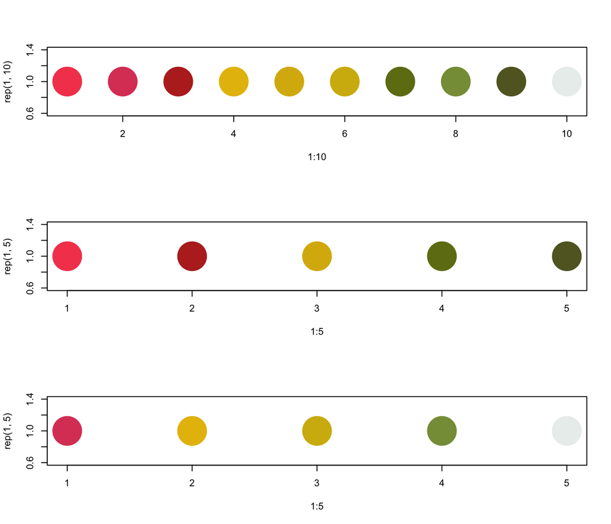

```r
# manual palette
#Color picker samples from Brugmansia image:
#reds (bottom): #F5485B, #DC4465, #B92C25
#yellows: (middle): #E6BD09, #D9B509, #D2B60A
#greens (top & bird): #6F7B16,#859B44,#60642A
manual.col <- c('#F5485B', '#DC4465', '#B92C25','#E6BD09', '#D9B509', '#D2B60A','#6F7B16','#859B44','#60642A')
manual.cols <- alpha(manual.col)
RYG6 <- c(manual.cols,'#EAEFEDFF')
par(mfrow=c(3,1))
plot(1:10,rep(1,10),pch=20,cex=10,col=RYG6)
plot(1:5,rep(1,5),pch=20,cex=10,col=RYG6[c(TRUE, FALSE)])
plot(1:5,rep(1,5),pch=20,cex=10,col=RYG6[c(F,T)])
```